# Plotting nestedLogit models with ggplot2

Michael Friendly and John Fox

2023-06-22

Load the packages we’ll use here:

```r
library(nestedLogit)    # Nested Dichotomy Logistic Regression Models
library(knitr)          # A General-Purpose Package for Dynamic Report Generation in R
library(dplyr)          # A Grammar of Data Manipulation
library(tidyr)          # Tidy Messy Data
library(ggplot2)        # Create Elegant Data Visualisations Using the Grammar of Graphics
library(geomtextpath)   # Curved Text in 'ggplot2'
```

The main vignette illustrated the basic plot method, `plot.nestedLogit()` in the package. However, for better control of the details and possibly more pleasing graphs, it is useful to describe how graphs can be constructed using `ggplot2` (Wickham et al., 2023). We’ll use the same example of women’s labor force participation, using the original dichotomies:

```r
data(Womenlf, package = "carData")
comparisons <- logits(work=dichotomy("not.work", c("parttime", "fulltime")),
                      full=dichotomy("parttime", "fulltime"))

wlf.nested <- nestedLogit(partic ~ hincome + children,
                          dichotomies = comparisons,
                          data=Womenlf)
```

The advantages of this approach are that

- you can handle more complicated designs with more predictors by faceting,
- it allows you to plot either the fitted probabilities or their transformed logits,
- you can also obtain plots for log odds corresponding to each of the dichotomies which comprise the nested logit model.

As we will illustrate, this provides a nice visual interpretation of the alternative specification of dichotomies for the `Womenlf` data discussed in the section “Alternative models for the `Womenlf` data” of the main vignette.

## Fitted probabilities

To draw a plot, it is sufficient to calculate predicted probabilities over a grid of values of the predictor variables. Here, we select a range of 0 - 45 in steps of 5, combined with the two values of `children`.

```r
new <- expand.grid(hincome=seq(0, 45, by = 5),
                   children=c("absent", "present"))

pred.nested <- predict(wlf.nested, newdata = new)
names(pred.nested)
```

```
#> [1] "p"        "logit"    "se.p"     "se.logit" ".data"
```

```r
head(pred.nested[["p"]])
```

```
#>   not.work parttime fulltime
#> 1   0.2082  0.02372   0.7681
#> 2   0.2452  0.03785   0.7169
#> 3   0.2864  0.05907   0.6545
#> 4   0.3315  0.08936   0.5791
#> 5   0.3800  0.12944   0.4906
#> 6   0.4309  0.17691   0.3922
```

However, `ggplot` wants the data in long format. This is easily done using the `as.data.frame()` method, which also includes the values of the predictors in the `newdata` data set:

```r
plotdata <- as.data.frame(pred.nested, newdata=new)
head(plotdata)
```

```
#>   hincome children response       p    se.p   logit se.logit
#> 1       0   absent not.work 0.20820 0.06326 -1.3358   0.3838
#> 2       0   absent parttime 0.02372 0.01775 -3.7176   0.7666
#> 3       0   absent fulltime 0.76809 0.06386  1.1975   0.3585
#> 4       5   absent not.work 0.24522 0.05799 -1.1243   0.3133
#> 5       5   absent parttime 0.03785 0.02222 -3.2356   0.6101
#> 6       5   absent fulltime 0.71694 0.05933  0.9293   0.2923
```

## Plotting with `ggplot2`

Then we can plot probability against one predictor, use `color` to distinguish the levels of the response (`partic`) and facet the plot by `children`. The point-wise standard errors are drawn in a 68% confidence envelope using `geom_ribbon()`. We’ve also plotted the predicted values as points to show where the predictions are obtained.

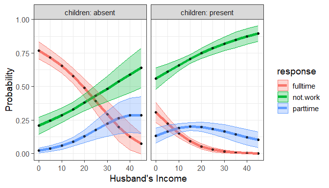

**ggplot**: Predicted probabilities of working at all or working part time or full time versus husband’s income, by `children`

```r
theme_set(theme_bw(base_size = 14))

gg1 <- ggplot(plotdata,
       aes(x=hincome, y=p, color=response)) +
  geom_line(linewidth = 2) +
  geom_point(size = 1.5, shape = 16, color = "black") +
  labs(x="Husband's Income", y= "Probability") +
  facet_wrap(~ children, labeller = label_both) +
  geom_ribbon(aes(ymin=p - se.p,
                  ymax=p + se.p,
                  fill = response), alpha = 0.3)

gg1
```

It is noteworthy that the confidence envelopes are wider for not-working women at higher levels of husband’s income, where there are fewer observations.

### Direct labels

Plot legends are somewhat hard to read and take up unnecessary space in the plot, so it is often better to label the curves directly. The `geomtextpath` package (Cameron & van den Brand, 2022) produces a nicer plot.

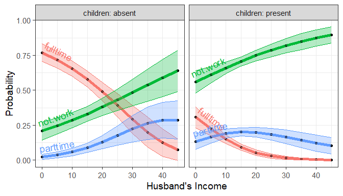

The same plot using direct labels on the curves rather than a legend.`

```r
gg1 + geom_textline(aes(label = response),
                    hjust = -0.01, vjust=-0.5, size=5) +
  theme(legend.position = "none")
```

### Plotting log-odds

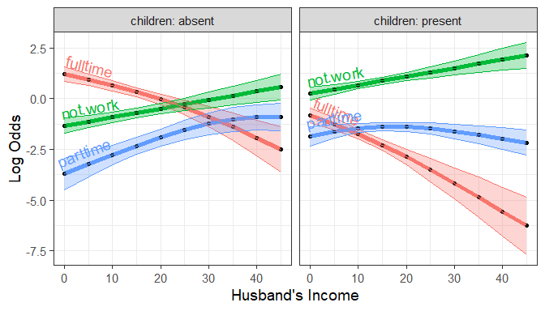

Predicted log odds of working at all or working part time or full time versus husband’s income, by `children`

```r
ggplot(plotdata,
       aes(x=hincome, y=logit, color=response)) +
  geom_line(linewidth = 2) +
  geom_point(size = 1.5, shape = 16, color = "black") +
  labs(x="Husband's Income", y= "Log Odds") +
  facet_wrap(~ children, labeller = label_both) +
  geom_ribbon(aes(ymin=logit - se.logit,
                  ymax=logit + se.logit,
                  fill = response), alpha = 0.3) +
  geom_textline(aes(label = response),
                hjust = -0.01, vjust=-0.5, size=5) +
  theme(legend.position = "none")
```

## Predicted logit values for the dichotomies

The nested logit model `wlf.nested` comprises the two binary logistic regression models for the `work` and `full` dichotomies. We can plot these as follows.

```r
names(models(wlf.nested))
```

```
#> [1] "work" "full"
```

The `predict()` method can also generate predicted values and their standard errors for the logits of these dichotomies, using the `model = "dichotomies"` argument:

```r
pred.dichot <- predict(wlf.nested, newdata = new,
                       model = "dichotomies")
str(pred.dichot)
```

```
#> List of 3
#>  $ work :'data.frame':   20 obs. of  3 variables:
#>   ..$ fit           : num [1:20] 1.336 1.124 0.913 0.701 0.49 ...
#>   ..$ se.fit        : num [1:20] 0.384 0.313 0.262 0.242 0.261 ...
#>   ..$ residual.scale: num [1:20] 1 1 1 1 1 1 1 1 1 1 ...
#>  $ full :'data.frame':   20 obs. of  3 variables:
#>   ..$ fit           : num [1:20] 3.48 2.94 2.41 1.87 1.33 ...
#>   ..$ se.fit        : num [1:20] 0.767 0.613 0.489 0.423 0.443 ...
#>   ..$ residual.scale: num [1:20] 1 1 1 1 1 1 1 1 1 1 ...
#>  $ .data:'data.frame':   20 obs. of  2 variables:
#>   ..$ hincome : num [1:20] 0 5 10 15 20 25 30 35 40 45 ...
#>   ..$ children: Factor w/ 2 levels "absent","present": 1 1 1 1 1 1 1 1 1 1 ...
#>   ..- attr(*, "out.attrs")=List of 2
#>   .. ..$ dim     : Named int [1:2] 10 2
#>   .. .. ..- attr(*, "names")= chr [1:2] "hincome" "children"
#>   .. ..$ dimnames:List of 2
#>   .. .. ..$ hincome : chr [1:10] "hincome= 0" "hincome= 5" "hincome=10" "hincome=15" ...
#>   .. .. ..$ children: chr [1:2] "children=absent" "children=present"
#>  - attr(*, "model")= chr "wlf.nested"
#>  - attr(*, "dichotomies")= chr [1:2] "work" "full"
#>  - attr(*, "class")= chr "predictDichotomies"
```

Transforming this to a data frame, we get an analogous result for plotting:

```r
plotlogit <- as.data.frame(pred.dichot, newdata = new)
head(plotlogit)
```

```
#>   hincome children response  logit se.logit
#> 1       0   absent     work 1.3358   0.3838
#> 2       5   absent     work 1.1243   0.3133
#> 3      10   absent     work 0.9127   0.2620
#> 4      15   absent     work 0.7012   0.2422
#> 5      20   absent     work 0.4897   0.2613
#> 6      25   absent     work 0.2781   0.3121
```

Then, plot the `logit` vs. husband’s income, with separate curves for the two sub-models:

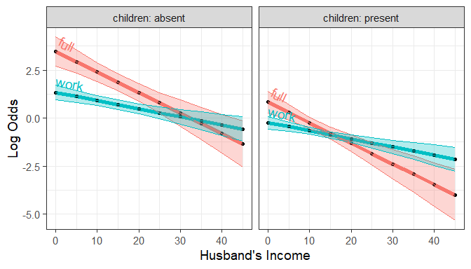

Predicted logits for the two dichotomies, `work` and `full` versus `hincome`, by `children`

```r
ggplot(plotlogit,
       aes(x=hincome, y=logit, color=response)) +
  geom_line(linewidth = 2) +
  geom_point(size = 1.5, shape = 16, color = "black") +
  labs(x="Husband's Income", y= "Log Odds") +
  facet_wrap(~ children, labeller = label_both) +
  geom_ribbon(aes(ymin=logit - se.logit,
                  ymax=logit + se.logit,
                  fill = response), alpha = 0.3) +
  geom_textline(aes(label = response),
                hjust = -0.01, vjust=-0.5, size=5) +
  theme(legend.position = "none")
```

Or, interchanging the roles of `children` and `response`, we can plot these the other way, faceting by `response`.

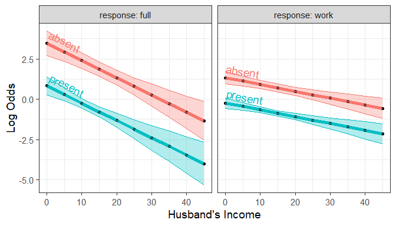

Predicted logits for the two dichotomies, `work` and `full` versus `hincome`, by `response`

```r
ggplot(plotlogit,
       aes(x=hincome, y=logit, color=children)) +
  geom_line(linewidth = 2) +
  geom_point(size = 1.5, shape = 16, color = "black") +
  labs(x="Husband's Income", y= "Log Odds") +
  facet_wrap(~ response, labeller = label_both) +
  geom_ribbon(aes(ymin=logit - se.logit,
                  ymax=logit + se.logit,
                  fill = children), alpha = 0.3) +
  geom_textline(aes(label = children),
                hjust = -0.01, vjust=-0.5, size=5) +
  theme(legend.position = "none")
```

This nicely illustrates the nature of the fitted logit models: The lines in each panel have the same slopes for the two levels of `children`, differing only in their intercepts. The `full` distinction between working full-time vs. part-time decreases faster with husband’s income than for the `work` dichotomy between not working at all and working either part-time or full-time.

## Alternative model

In the main vignette we mentioned that an alternative set of nested dichotomies first contrasts full-time work with the other categories, {full-time} vs. {not working, part-time}, and then {not working} vs. {part-time}.

```r
wlf.nested.alt <- nestedLogit(partic ~ hincome + children,
                              logits(full=dichotomy(nonfulltime=c("not.work", "parttime"), "fulltime"),
                                     part=dichotomy("not.work", "parttime")),
                              data=Womenlf)
```

Proceeding in the same way as above, we get predicted logits and standard errors for each of the dichotomies.

```r
pred.dichot.alt <- predict(wlf.nested.alt, newdata = new,
                       model = "dichotomies")
plotlogit.alt <- as.data.frame(pred.dichot.alt, newdata = new)
head(plotlogit.alt)
```

```
#>   hincome children response   logit se.logit
#> 1       0   absent     full  1.7696   0.4690
#> 2       5   absent     full  1.2762   0.3577
#> 3      10   absent     full  0.7827   0.2723
#> 4      15   absent     full  0.2893   0.2421
#> 5      20   absent     full -0.2042   0.2852
#> 6      25   absent     full -0.6976   0.3772
```

Plotting these as before:

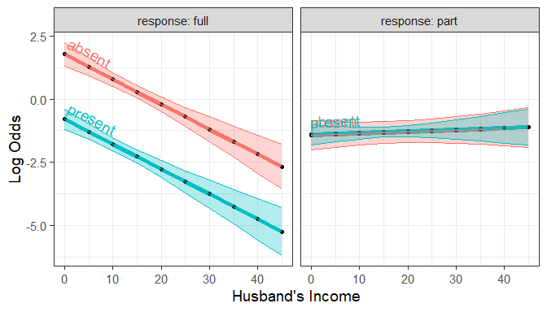

```r
ggplot(plotlogit.alt,
       aes(x=hincome, y=logit, color=children)) +
  geom_line(linewidth = 2) +
  geom_point(size = 1.5, shape = 16, color = "black") +
  labs(x="Husband's Income", y= "Log Odds") +
  facet_wrap(~ response, labeller = label_both) +
  geom_ribbon(aes(ymin=logit - se.logit,
                  ymax=logit + se.logit,
                  fill = children), alpha = 0.3) +
  geom_textline(aes(label = children),
                hjust = -0.01, vjust=-0.5, size=5) +
  theme(legend.position = "none")
```

## References

Cameron, A., & van den Brand, T. (2022). *Geomtextpath: Curved text in ggplot2*. Retrieved from https://allancameron.github.io/geomtextpath/

Wickham, H., Chang, W., Henry, L., Pedersen, T. L., Takahashi, K., Wilke, C., … Dunnington, D. (2023). *ggplot2: Create elegant data visualisations using the grammar of graphics*. Retrieved from https://CRAN.R-project.org/package=ggplot2